# Count based regression models

John Fieberg

2026-03-25

## Preamble

Load packages, etc

```r
library(ggplot2)
theme_set(theme_bw())
knitr::opts_chunk$set(fig.align='center', out.width = "55%", fig.height = 5, fig.width =6)
set.seed(12111)
library(kableExtra) # for tables
options(kableExtra.html.bsTable = T)
library(ggthemes) # for colorblind pallete
 library(dplyr) # for data wrangling
library(R2jags) # for fitting models using JAGS
library(MCMCvis) # for summarizing JAGS output
#library(mcmcplots) # for denplots and traplots
library(Data4Ecologists)
data(slugs)
data("longnosedace")
```

## Fit Poisson model using JAGS

```r
pois.fit<-function(){

  # Priors for regression parameters
  for(i in 1:7){
    beta[i] ~ dnorm(0, 0.001)
  }
  # Likelihood
  for(i in 1:n){
    dace[i] ~ dpois(lambda[i])
    log(lambda[i]) <- beta[1] + beta[2]*acreage[i] + beta[3]*so4[i] +
      beta[4]*no3[i]+ beta[5]*maxdepth[i]+beta[6]*do2[i] + beta[7]*temp[i]
  }

  # Fit assessments

  for(i in 1:n){
    # Calculate Pearson residuals and squared residuals
    Presi[i] <- (dace[i]-lambda[i])/sqrt(lambda[i])   # Pearson residuals
    D[i] <-  pow(Presi[i], 2) # squared residuals

    # Have JAGS simulate new observations and calculate
    # residuals and squared residuals
    dace.new[i] ~  dpois(lambda[i])
    Presi.new[i] <- (dace.new[i]-lambda[i])/sqrt(lambda[i])    # Pearson residuals
    D.new[i] <- pow(Presi.new[i], 2)
  }

  # Add up discrepancy measures
  fit <- sum(D[])
  fit.new <- sum(D.new[])
}


# Bundle data, here we need to list our response variable,
# all of our predictor variables, and n= nrow(longnosedace)
jagsdata <- list(dace=longnosedace$longnosedace,
                 acreage =  longnosedace$acreage,
                 do2 = longnosedace$do2,
                 maxdepth = longnosedace$maxdepth,
                 no3 = longnosedace$no3,
                 so4 = longnosedace$so4,
                 temp = longnosedace$temp, n = nrow(longnosedace))


# Parameters to estimate
params <- c("beta", "lambda", "Presi", "fit", "fit.new", "dace.new")


# Start Gibbs sampler
out.pois <- jags.parallel(data = jagsdata, parameters.to.save = params,
                          model.file = pois.fit, n.thin = 2, n.chains = 3, n.burnin = 5000,
                          n.iter = 20000)
```

Look at results for the regression coefficients and also make sure that out sampler has converged to the same place for all 3 chains

```r
MCMCsummary(out.pois, params="beta", round=3)
```

```
##           mean    sd   2.5%    50%  97.5% Rhat n.eff
## beta[1] -1.421 0.305 -2.019 -1.423 -0.821    1 14826
## beta[2]  0.000 0.000  0.000  0.000  0.000    1 18533
## beta[3] -0.004 0.004 -0.012 -0.004  0.003    1 14789
## beta[4]  0.191 0.011  0.169  0.191  0.214    1 15552
## beta[5]  0.015 0.001  0.013  0.015  0.016    1 16679
## beta[6]  0.188 0.024  0.141  0.188  0.235    1 15931
## beta[7]  0.084 0.007  0.072  0.084  0.097    1 17868
```

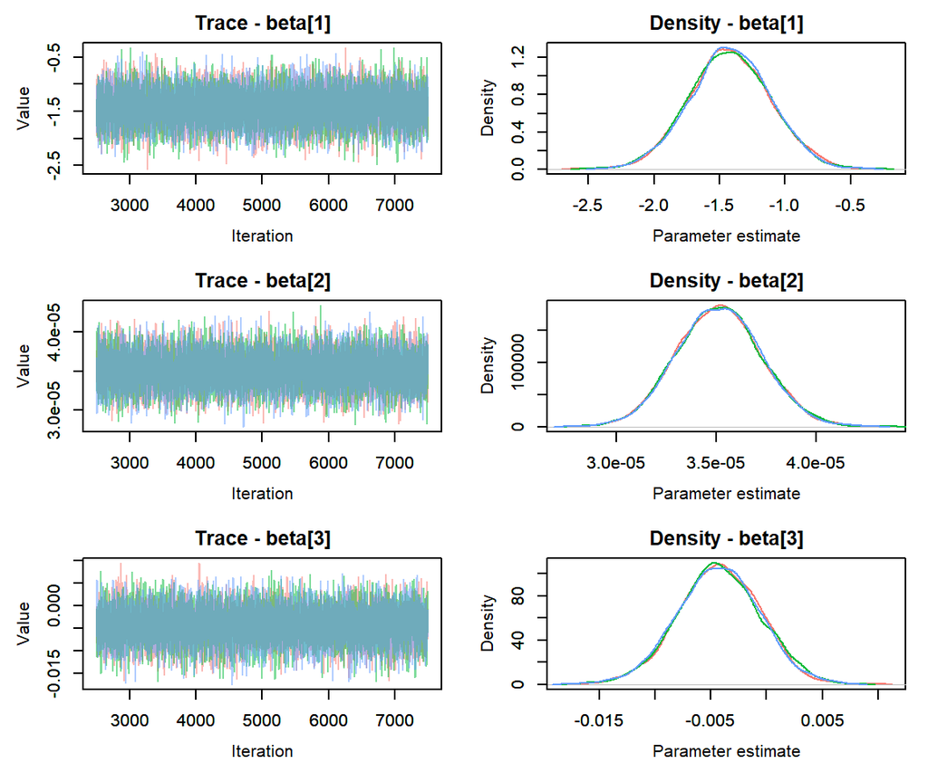

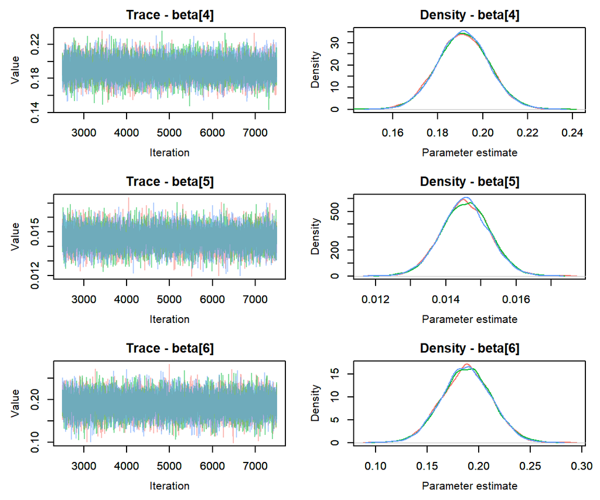

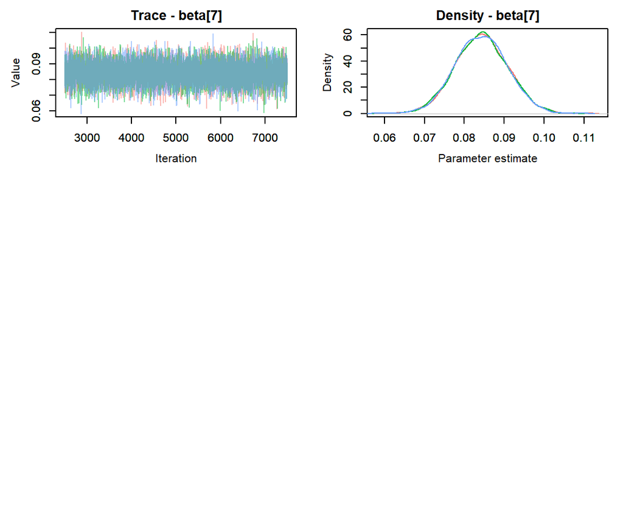

```r
MCMCtrace(out.pois, params="beta",  pdf=FALSE, ind = TRUE)
```

Let’s plot Pearson residuals versus fitted values for the Poisson regression model

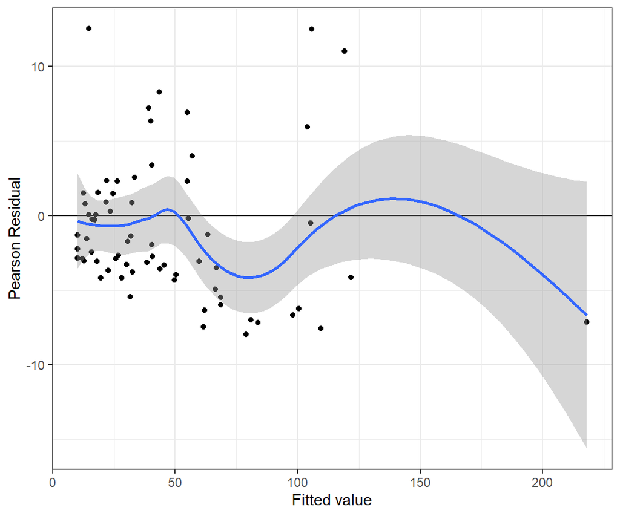

```r
bresids <- MCMCpstr(out.pois, params = "Presi", func = mean)$Presi
bfitted <- MCMCpstr(out.pois, params = "lambda", func = mean)$lambda
jagsPfit <- data.frame(resid = bresids, fitted = bfitted)
ggplot(jagsPfit, aes(fitted, resid)) + geom_point() +
  geom_hline(yintercept = 0) + geom_smooth() +
  xlab("Fitted value") + ylab("Pearson Residual")
```

GOF test

```r
fitstats <- MCMCpstr(out.pois, params = c("fit", "fit.new"), type = "chains")
T.extreme <- fitstats$fit.new >= fitstats$fit
(p.val <- mean(T.extreme))
```

```
## [1] 0
```

## Fit negative binomial model using JAGS

This time, we will use the design matrix to make it easier to specify the model.

```r
# Bundle data, here we will use the design matrix from R
xmat <- model.matrix(~acreage + do2 + maxdepth + no3 + so4 + temp,
                     data = longnosedace)

jagsdata <- list(x = xmat, np = ncol(xmat),
                 n = nrow(longnosedace),
                 longnosedace = longnosedace$longnosedace)

nb.fit<-function(){

  # Priors for regression parameters
  for(i in 1:np){
    beta[i] ~ dnorm(0,0.001)
  }
  theta~dunif(0,50)
  for(i in 1:n){
    log(mu[i]) <- inprod(beta[], x[i,])
    p[i] <- theta/(theta+mu[i])
    longnosedace[i] ~ dnegbin(p[i],theta)

    # Fit assessments
    Presi[i] <- (longnosedace[i] - mu[i]) / sqrt(mu[i]+mu[i]*mu[i]/theta) # Pearson residuals
    dace.new[i] ~ dnegbin(p[i],theta)    # Replicate data set
    Presi.new[i] <- (dace.new[i] - mu[i]) / sqrt(mu[i]+mu[i]*mu[i]/theta) # Pearson residuals
    D[i] <- pow(Presi[i], 2)
    D.new[i] <- pow(Presi.new[i], 2)
  }

  # Add up discrepancy measures
  fit <- sum(D[])
  fit.new <- sum(D.new[])
}


# Parameters to estimate
params <- c("mu", "beta", "theta","Presi", "fit", "fit.new", "dace.new")


# Start Gibbs sampler
out.nb <- jags.parallel(data = jagsdata, parameters.to.save = params,
                        model.file = nb.fit, n.thin = 2, n.chains = 3, n.burnin = 5000,
                        n.iter = 20000)
```

Density and trace plots

```r
MCMCsummary(out.nb, params = "beta")
```

```
##                  mean           sd          2.5%           50%         97.5%
## beta[1] -3.013240e+00 1.494289e+00 -5.951003e+00 -2.993696e+00 -1.207082e-01
## beta[2]  4.754560e-05 1.427304e-05  2.103897e-05  4.707592e-05  7.710689e-05
## beta[3]  3.487101e-01 1.231051e-01  1.172398e-01  3.437111e-01  6.061997e-01
## beta[4]  9.658390e-03 3.547113e-03  3.050214e-03  9.573121e-03  1.683594e-02
## beta[5]  2.094254e-01 5.830753e-02  9.669962e-02  2.080339e-01  3.275777e-01
## beta[6] -9.688781e-05 1.494110e-02 -2.788321e-02 -6.920098e-04  3.096653e-02
## beta[7]  9.426342e-02 3.604377e-02  2.148934e-02  9.485678e-02  1.628955e-01
##         Rhat n.eff
## beta[1] 1.02    88
## beta[2] 1.00  7992
## beta[3] 1.03   141
## beta[4] 1.00  2527
## beta[5] 1.00  5449
## beta[6] 1.00  4195
## beta[7] 1.01   401
```

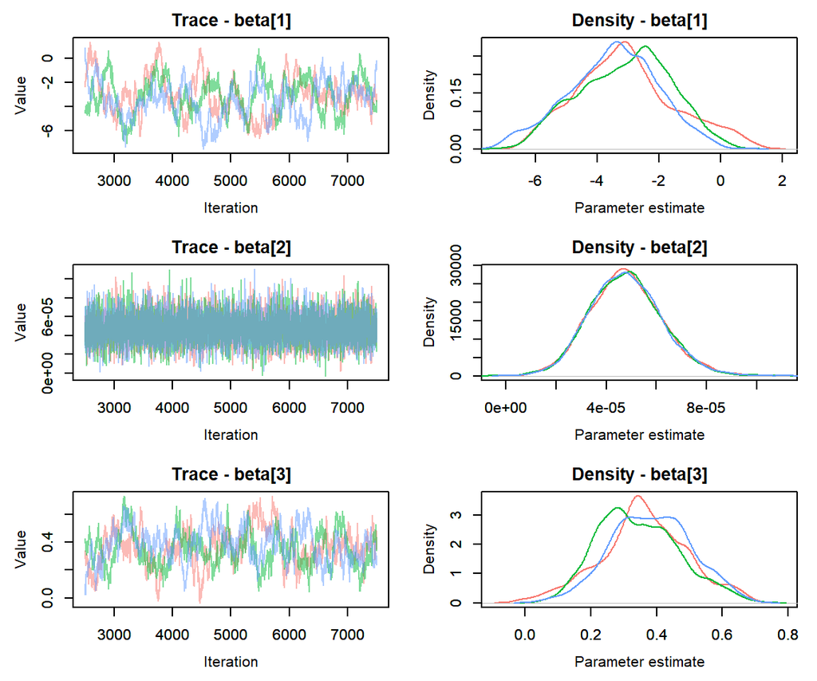

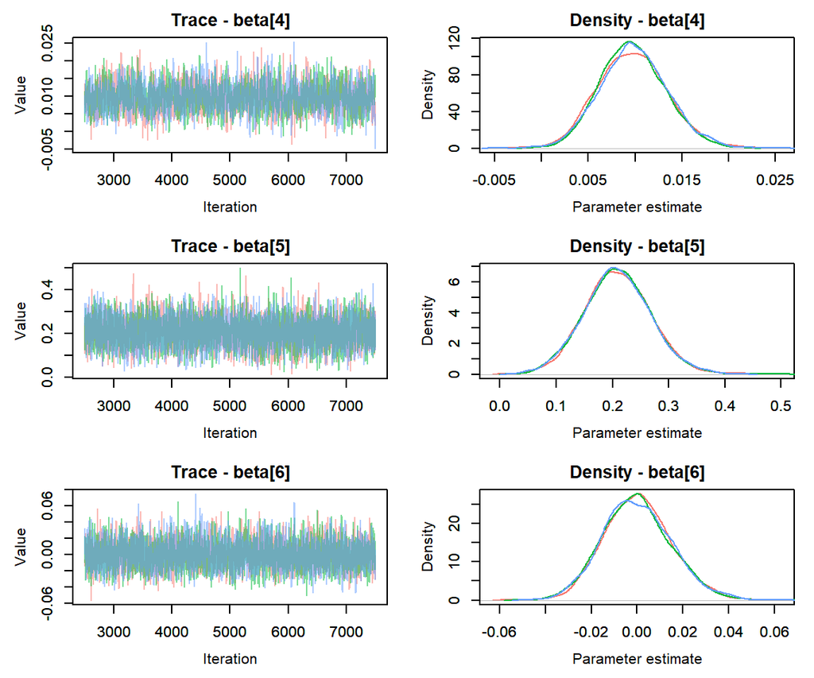

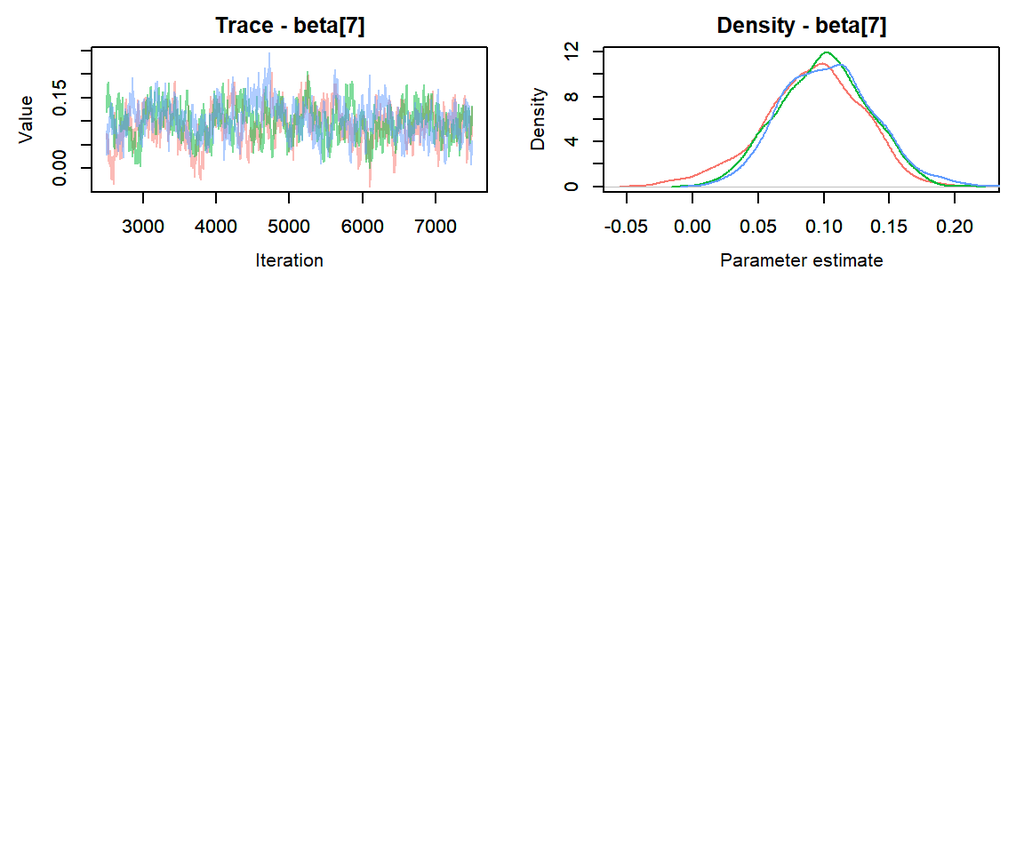

```r
MCMCtrace(out.nb, pdf=FALSE, ind = TRUE, params = "beta")
```

Let’s again plot Pearson residuals versus fitted values for the Negative Binomial regression model

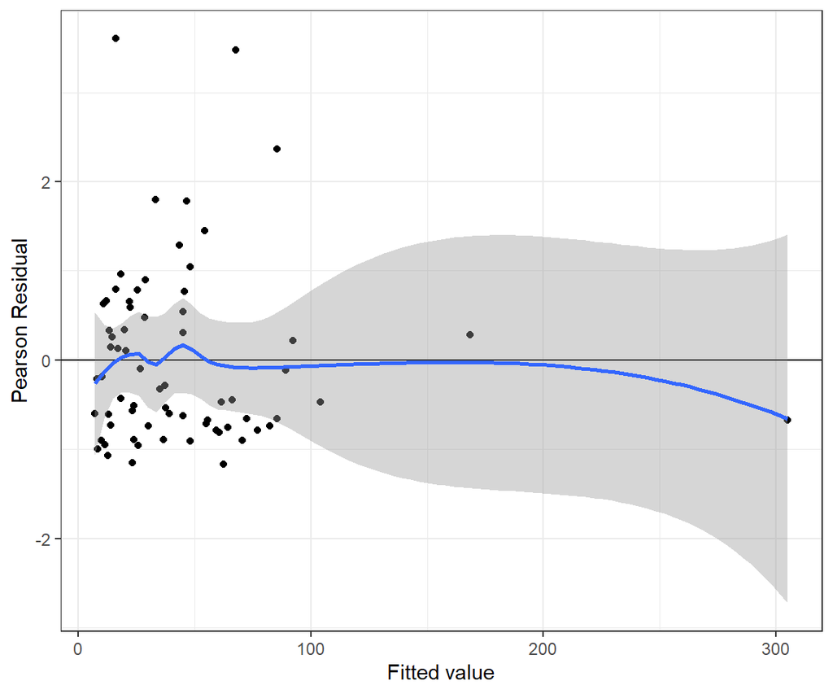

```r
nbresids <- MCMCpstr(out.nb, params = "Presi", func = mean)$Presi
nbfitted <- MCMCpstr(out.nb, params = "mu", func = mean)$mu
jagsnbfit <- data.frame(resid = nbresids, fitted = nbfitted)
ggplot(jagsnbfit, aes(fitted, resid)) + geom_point() +
  geom_hline(yintercept = 0) + geom_smooth() +
  xlab("Fitted value") + ylab("Pearson Residual")
```

```r
# GOF test
fitstats <- MCMCpstr(out.nb, params = c("fit", "fit.new"), type = "chains")
T.extreme <- fitstats$fit.new >= fitstats$fit
(p.val <- mean(T.extreme))
```

```
## [1] 0.3143556
```